# Homework #1

Austin Nebel

## Visualizing the Ratings

```r
choco <- read.csv("https://raw.githubusercontent.com/xdaiISU/ds202materials/master/hwlabs/data/choco.csv")
str(choco)
```

```
## 'data.frame':    2312 obs. of  13 variables:
##  $ REF                 : int  2454 2458 2454 797 797 1015 1019 1011 1019 1011 ...
##  $ Company             : chr  "5150" "5150" "5150" "A. Morin" ...
##  $ Location            : chr  "U.S.A." "U.S.A." "U.S.A." "France" ...
##  $ Date                : int  2019 2019 2019 2012 2012 2013 2013 2013 2013 2013 ...
##  $ Bean_Origin         : chr  "Madagascar" "Dominican Republic" "Tanzania" "Peru" ...
##  $ Specific_Bean_Origin: chr  "Bejofo Estate, batch 1" "Zorzal, batch 1" "Kokoa Kamili, batch 1" "Peru" ...
##  $ Cocoa_Percent       : num  76 76 76 63 70 70 63 70 70 70 ...
##  $ Ingredients         : chr  "3- B,S,C" "3- B,S,C" "3- B,S,C" "4- B,S,C,L" ...
##  $ Characteristics1    : chr  "cocoa" "cocoa" "rich cocoa" "fruity" ...
##  $ Characteristics2    : chr  "blackberry" "vegetal" "fatty" "melon" ...
##  $ Characteristics3    : chr  "full body" "savory" "bready" "roasty" ...
##  $ Characteristics4    : chr  NA NA NA NA ...
##  $ Rating              : num  3.75 3.5 3.25 3.75 3.5 4 4 3.75 3.5 3.25 ...
```

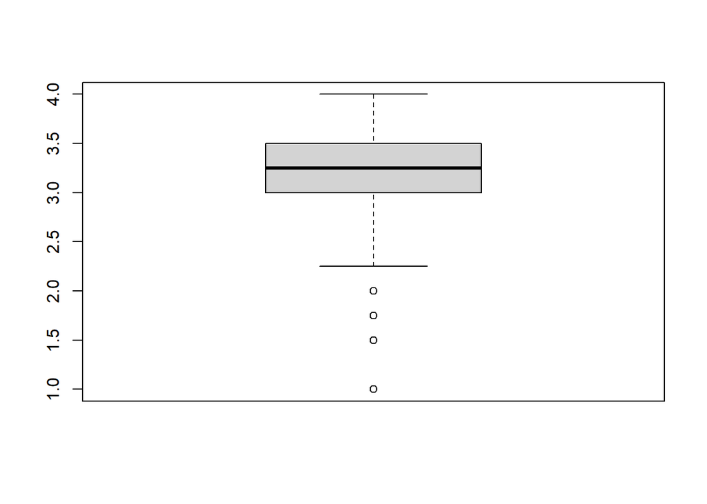

```r
boxplot(choco$Rating)
```

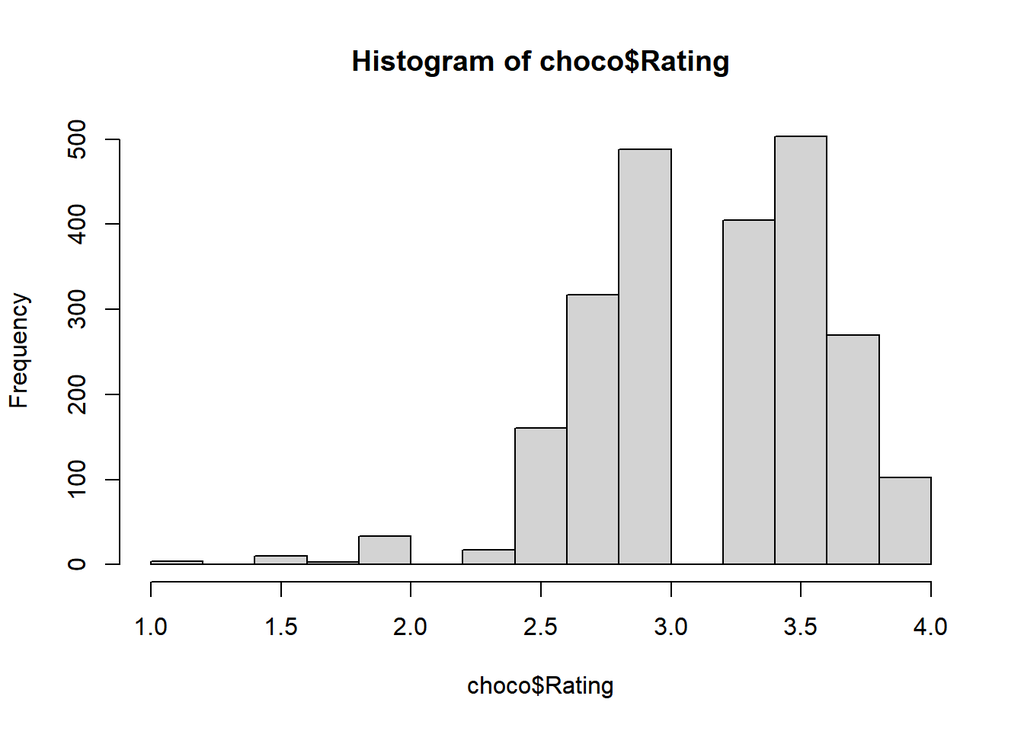

```r
hist(choco$Rating)
```

The ratings seem to generally lean towards the high side of the scale. Based off of the box plot, almost 70% of the chocolates are rated at over 3.0/5.0 and there are only a few outliers near the lower end of the scale. From the histogram it can be clearly seen that almost all chocolates received a rating of over 2.5.

## Ratings and Locations

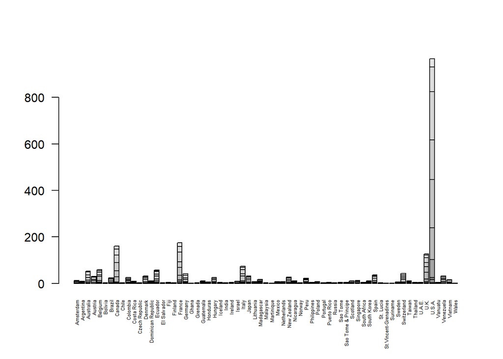

```r
counts <- table(choco$Rating, choco$Location)
barplot(counts, las=2, cex.names=0.4)
```

The amount of ratings are definitely dependant on location. As seen it the bar graph above, the U.S.A has the highest amount ratings and all other locations are much lower.

## Ratings and Cocoa Percentage

```r
pr <- choco[,c("Cocoa_Percent", "Rating")]
summary(pr)
```

```
##  Cocoa_Percent        Rating
##  Min.   : 42.00   Min.   :1.000
##  1st Qu.: 70.00   1st Qu.:3.000
##  Median : 70.00   Median :3.250
##  Mean   : 71.65   Mean   :3.184
##  3rd Qu.: 75.00   3rd Qu.:3.500
##  Max.   :100.00   Max.   :4.000
```

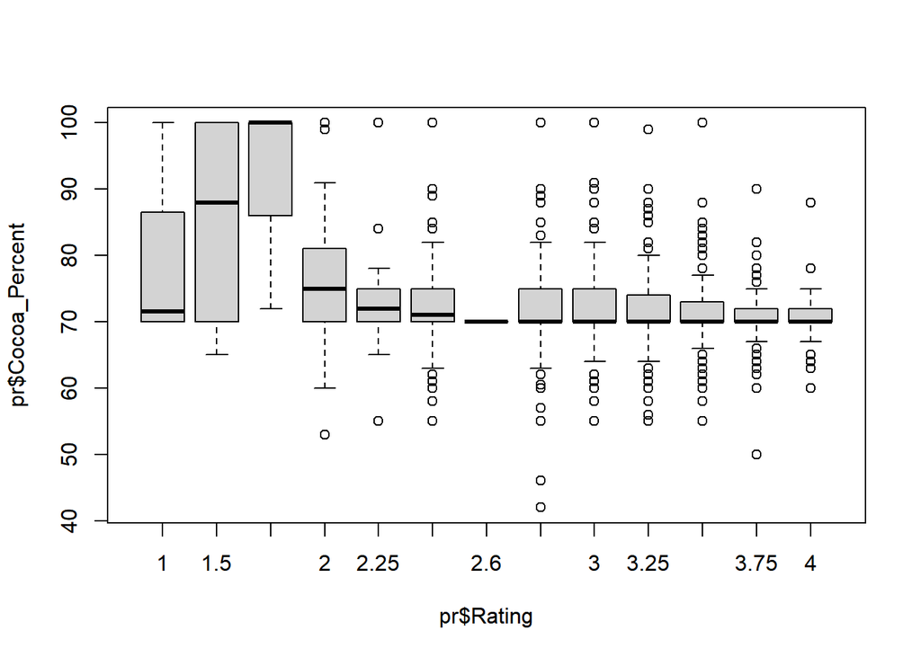

```r
percent_by_rating <- pr$Cocoa_Percent ~ pr$Rating
boxplot(percent_by_rating)
```

The boxplot shows the range of percents of chocoa for each rating of chocolate. Interestingly, the highest scoring chocolates had a very small range of percentages of chocoa and where overall much lower percentages compared to the worst rated chocolates. However, the average percentages of cocoa are very close accross all chocolates; they are almost all within 70-75% range of cocoa. From this, it appears that the amount of chocoa does influence the ratings due to the highest rated chocolates all being within a very similar, small range.

## Bean Origins and Flavor

```r
or <- choco[,c("Bean_Origin", "Rating")]
table(or)
```

```
##                        Rating
## Bean_Origin              1 1.5 1.75  2 2.25 2.5 2.6 2.75  3 3.25 3.5 3.75  4
##   Australia              0   0    0  0    0   0   0    1  0    1   0    1  0
##   Belize                 0   0    0  0    0   1   0    9 17   18  14    6  2
##   blend                  0   0    0  0    0   0   0    0  1    0   0    0  0
##   Blend                  3   5    0 11    0   9   0   20 30   21  27   18  7
##   Bolivia                0   0    0  1    0   7   0    9 17   15  10    8  5
##   Bolvia                 0   0    0  0    0   0   0    0  0    1   0    0  0
##   Brazil                 0   0    1  0    0   3   0    8 18   12  20    9  4
##   Burma                  0   0    0  0    0   0   0    0  1    0   0    0  0
##   Cameroon               0   0    0  0    0   0   0    0  2    1   0    0  0
##   Colombia               0   0    0  1    0   3   0   11 16   13   9    8  5
##   Congo                  0   0    0  0    0   0   0    1  2    3   3    2  0
##   Costa Rica             0   0    0  1    0   3   0    5 12    9   9    2  2
##   Cuba                   0   0    0  0    0   1   0    1  2    2   3    3  0
##   Dominican Republic     0   0    0  1    2  11   1   28 46   42  39   36  0
##   DR Congo               0   0    0  0    0   0   0    0  1    0   0    0  0
##   Ecuador                1   3    0  6    0  22   0   24 31   37  56   24  8
##   El Salvador            0   0    0  0    0   0   0    2  2    2   0    0  0
##   Fiji                   0   0    0  0    0   2   0    3  3    4   2    1  0
##   Gabon                  0   0    0  0    0   0   0    0  0    1   0    0  0
##   Ghana                  0   1    0  1    0   4   0    5  9    2   9    4  2
##   Grenada                0   0    0  0    1   3   0    5  0    4   6    0  0
##   Guatemala              0   0    0  0    0   1   0    8 10   10  17    4  3
##   Haiti                  0   0    0  0    0   1   0    4  4    4   8    0  3
##   Honduras               0   0    0  0    0   1   0    5  2    5   7    3  0
##   India                  0   0    0  0    0   2   0    1  6    6   6    0  0
##   Indonesia              0   0    0  0    1   2   0    4  3    2   2    3  1
##   Ivory Coast            0   0    0  0    0   2   0    0  3    0   0    0  0
##   Jamaica                0   0    0  1    0   1   0    3  5    7   1    4  1
##   Liberia                0   0    0  0    0   0   0    1  0    2   0    0  0
##   Madagascar             0   0    0  0    1   5   0   23 40   21  44   19 10
##   Malaysia               0   0    0  0    0   1   0    1  2    2   1    0  0
##   Martinique             0   0    0  0    0   0   0    1  0    0   0    0  0
##   Mexico                 0   0    0  1    0   6   0    6 12    9   5    4  3
##   Nicaragua              0   0    0  1    0   4   0   13 15   21  24   12  2
##   Nigeria                0   0    0  0    0   0   0    1  1    1   0    0  0
##   Panama                 0   0    0  0    0   0   0    2  2    1   3    0  0
##   Papua New Guinea       0   0    0  0    0   2   0    5 12    9  14    3  4
##   Peru                   0   1    0  2    6  25   0   30 41   30  43   26 16
```

[output cut: 10 more lines]

```
##   St.Vincent-Grenadines  0   0    0  0    0   0   0    1  0    0   0    0  0
##   Sulawesi               0   0    0  0    0   0   0    0  0    1   0    0  0
##   Sumatra                0   0    0  0    0   0   0    0  1    0   0    0  0
##   Suriname               0   0    0  0    0   0   0    0  0    1   0    0  0
##   Taiwan                 0   0    0  0    0   1   0    0  0    1   0    0  0
##   Tanzania               0   0    0  2    0   2   0    8 12   16  13   10  1
##   Thailand               0   0    0  0    0   0   0    1  1    0   2    1  0
##   Tobago                 0   0    0  0    0   0   0    0  0    1   0    0  1
##   Togo                   0   0    0  0    0   0   0    1  1    0   1    0  0
##   Trinidad               0   0    0  0    0   3   0    6  6    6  12    5  0
##   U.S.A.                 0   0    0  1    0   2   0    3  6    5   7    6  0
##   Uganda                 0   0    0  0    0   4   0    4  1    0   1    1  0
##   Vanuatu                0   0    0  0    0   1   0    4  3    1   1    3  0
##   Venezuela              0   0    1  3    3  17   0   29 59   29  50   36 18
##   Vietnam                0   0    0  0    0   0   0    8 15   15  21    4  1
```

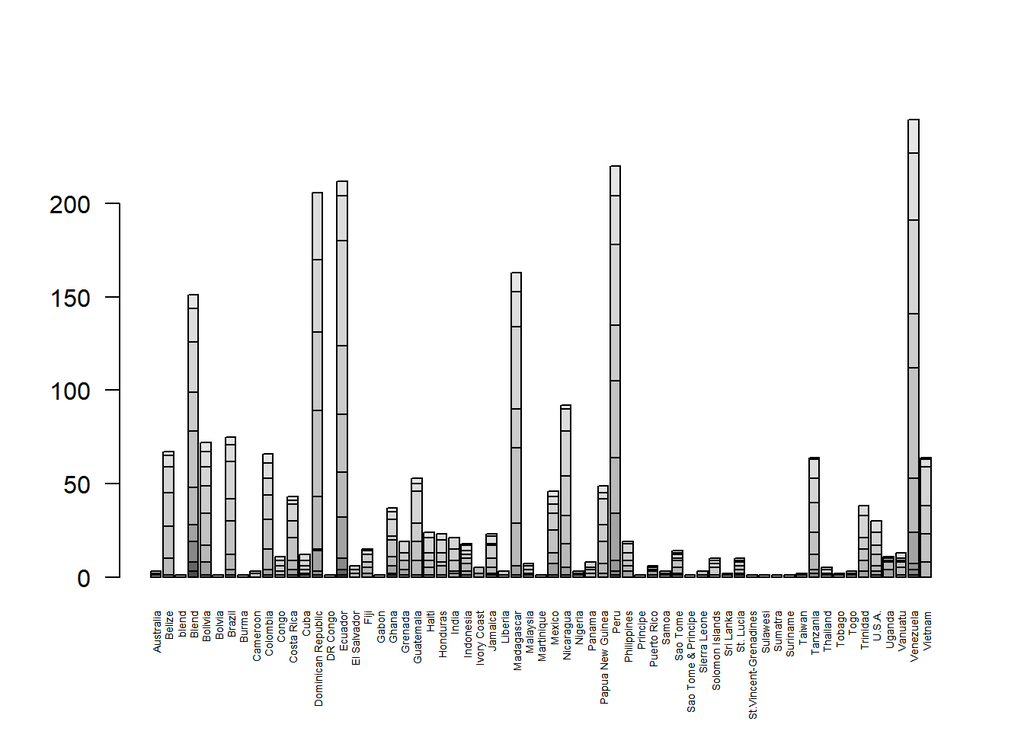

```r
origin_counts <- table(choco$Rating, choco$Bean_Origin)
barplot(origin_counts, las=2, cex.names=0.45)
```

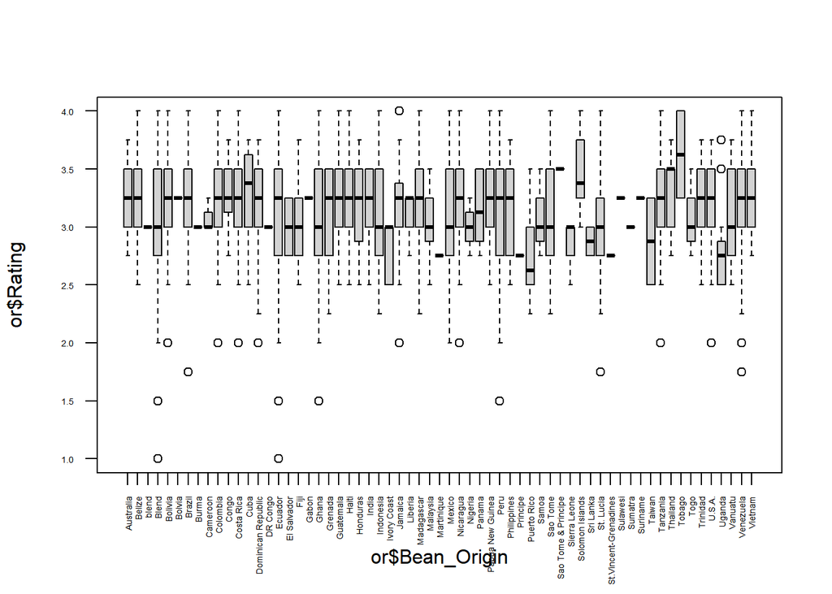

```r
origin_by_rating <-  or$Rating ~ or$Bean_Origin
boxplot(origin_by_rating, las=2, cex.axis=0.45)
```

From the boxplot above it can be seen that overall the quality of chocolates are very consistent across all bean harvesting locations.